# Outreach

Home | Research | Publications | Outreach | About | Gallery

I love talking to folks about science! Below are some organizations that I have been involved with. Please explore the pages below or send me an email if you are interested in an educational event hosted by one of these groups. We cater to audiences of a wide range of ages and backgrounds.

##### [Life Science Cafe](https://sci-stories.org/life-science-cafe/): Monthly talks and Q&A sessions with scientists.

##### [The Fernald Club](https://www.instagram.com/umassfernaldclub/): UMass Entomology Club; we share insect science with local students and other groups.

##### For more information about pollinators:

[UMass Extension Pollinator Website](https://ag.umass.edu/resources/pollinators)  
[UMass Extension Pollinator Facebook Page](https://www.facebook.com/UMassExtPollinators)  
[Western Mass Pollinator Network](https://www.wmassbees.org/)  
[Xerces Society for Invertebrate Conservation](https://www.xerces.org/)

[figure not shown]

[figure not shown]

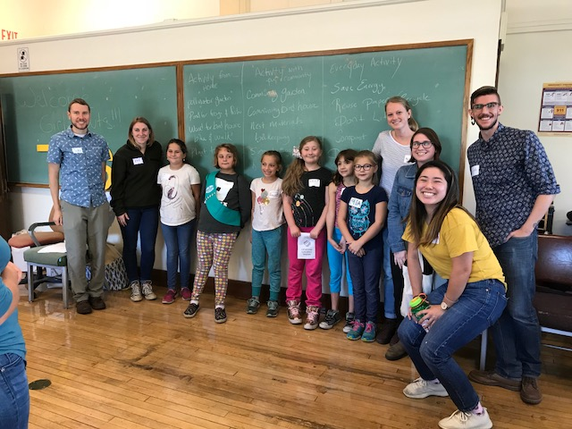

From left to right: making bee hotels with participants in an event hosted by the North Carolina Museum of Natural Science; hosting a workshop about pollinators and botany for middle school girls through the [Eureka! Program](https://www.girlsincvalley.org/); hosting a workshop for Girl Scouts to receive their “Animal Habitat Badge” through That’s Life Science.

[figure not shown]

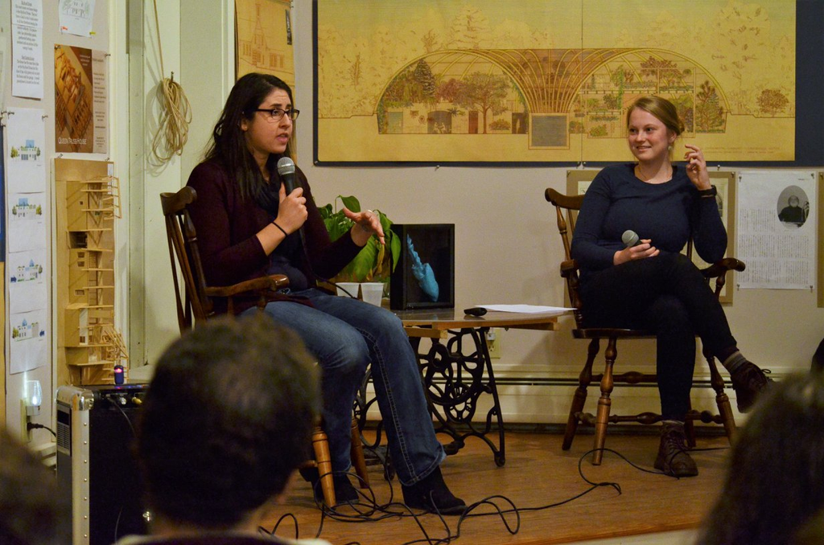

Left: Showing off the FlowCam at the NC Museum of Natural Sciences with other members of the Schnetzer Lab, Gabrielle and Dan. Right: Listening to Dr. Dara Orbach teach our Science Cafe audience about dolphin mating and genitalia.